# hw6

Exploring Spotify Songs' Popularity 🗞

Author: Frank Liang

## 1. Introduction

In general, we will be following the EDA process:

1. Get the data and gain **basic understanding**
2. **Wrangle** the data
3. **Profile** the data
4. Develop questions to investigate (form a **hypotheses**)
5. Use the data to **investigate** hypothesis
6. **Summarize** results and answer questions

## 2. Getting Familiar with the Data

In this section, we will get a feel for our data and tidy it up so that we can analyize it later.

### Problem 1

Let's take a look at the files in `utility/data` and think about what we can and will need to do with it.

**Write-up!** Describe the data in `data.csv`, answering questions including, but not limited to, these: Where does the data come from? How was it obtained? How many examples and features does the dataset have? What kinds of features are in the dataset? What values can these features take?

> `Hint` Consider the steps of EDA; what would you like to know about this dataset.

In these features, there are 1 primary feature(id), 12 numerical features + 2 dummy features (numerical type for only 0 or 1), 4 categorical features(one of them 'key' is encoded as from 0 to 11).

Primary type feature:

1.id (whose values are the unique Id of track generated by Spotify)

Numerical type used to describe related features of the song:

2.acousticness (values are ranges from 0 to 1)

3.danceability (values are ranges from 0 to 1)

4.energy (values are ranges from 0 to 1)

5.duration_ms (values are integer typically ranging from 200k to 300k)

6.instrumentalness (values are ranges from 0 to 1)

7.valence (values are ranges from 0 to 1)

8.popularity (values are ranges from 0 to 100)

9.tempo (values are float typically ranging from 50 to 150)

10.liveness (values are ranges from 0 to 1)

11.loudness (values are float typically ranging from -60 to 0)

12.speechiness (values are ranges from 0 to 1)

Dummy type used to describe related features of the song:

14.mode (0 = Minor, 1 = Major)

15.explicit (0 = No explicit content, 1 = Explicit content)

Categorical type used to describe related features of the song:

16.key (All keys on octave encoded as numerical values ranging from 0 to 11, starting on C as 0, C# as 1 and so on…)

17.artists(List of artists mentioned in the songs)

18.release_date(Date of release mostly in yyyy-mm-dd format, however precision of date may vary)

19.name(Name of the song)

Our target is to gain some insight about characteristics of popular vs. unpopular songs, so the popularity feature is likely to be our target.

### Problem 2

Let's do some data wrangling. Considering your description of the dataset from Problem 1, how should we clean this data?

In the cells below, **explain** and perform the steps that you need to prepare this data for further analysis. Make sure that your analysis and work is presented well and effectively communicates your work.

> `Hint` While our labs are not perfect, you can use them as an example of how you might do this. Also, you might want to come back to this step later on, since you might encounter problems with the data once you actually analyze it. Remember, you may add as many cells (for code and text) as you need below. Here — we gave you one for free!

```python
# this one is free!

#first we read our data in and look at the dataframe and features
import pandas as pd
spotify = pd.read_csv("./utility/data/data.csv")
#look at the shape and the feature names
print(spotify.shape)
spotify.head()
```

```
(174389, 19)
```

|  | acousticness | artists | danceability | duration_ms | energy | explicit | id | instrumentalness | key | liveness | loudness | mode | name | popularity | release_date | speechiness | tempo | valence | year |
| --- | --- | --- | --- | --- | --- | --- | --- | --- | --- | --- | --- | --- | --- | --- | --- | --- | --- | --- | --- |
| 0 | 0.991000 | ['Mamie Smith'] | 0.598 | 168333 | 0.224 | 0 | 0cS0A1fUEUd1EW3FcF8AEI | 0.000522 | 5 | 0.3790 | -12.628 | 0 | Keep A Song In Your Soul | 12 | 1920 | 0.0936 | 149.976 | 0.6340 | 1920 |
| 1 | 0.643000 | ["Screamin' Jay Hawkins"] | 0.852 | 150200 | 0.517 | 0 | 0hbkKFIJm7Z05H8Zl9w30f | 0.026400 | 5 | 0.0809 | -7.261 | 0 | I Put A Spell On You | 7 | 1920-01-05 | 0.0534 | 86.889 | 0.9500 | 1920 |
| 2 | 0.993000 | ['Mamie Smith'] | 0.647 | 163827 | 0.186 | 0 | 11m7laMUgmOKqI3oYzuhne | 0.000018 | 0 | 0.5190 | -12.098 | 1 | Golfing Papa | 4 | 1920 | 0.1740 | 97.600 | 0.6890 | 1920 |
| 3 | 0.000173 | ['Oscar Velazquez'] | 0.730 | 422087 | 0.798 | 0 | 19Lc5SfJJ5O1oaxY0fpwfh | 0.801000 | 2 | 0.1280 | -7.311 | 1 | True House Music - Xavier Santos & Carlos Gomi... | 17 | 1920-01-01 | 0.0425 | 127.997 | 0.0422 | 1920 |
| 4 | 0.295000 | ['Mixe'] | 0.704 | 165224 | 0.707 | 1 | 2hJjbsLCytGsnAHfdsLejp | 0.000246 | 10 | 0.4020 | -6.036 | 0 | Xuniverxe | 2 | 1920-10-01 | 0.0768 | 122.076 | 0.2990 | 1920 |

Let's look and clean the table columns(features) first

```python
print(spotify.columns)
```

```
Index(['acousticness', 'artists', 'danceability', 'duration_ms', 'energy',
       'explicit', 'id', 'instrumentalness', 'key', 'liveness', 'loudness',
       'mode', 'name', 'popularity', 'release_date', 'speechiness', 'tempo',
       'valence', 'year'],
      dtype='object')
```

The features look well formatted, so we don't have to format the column names then.

Since we are trying to gain some insight about characteristics of popular vs. unpopular songs (popularity will be our target), we have to consider which features are worth investigating and likely to be the characteristics of popular vs. unpopular songs.

1.id: Since all ids are unique for each tracks, they are unlikely to be related to the popularity. So we will drop the id columns for not interested.

2.name: Similarly, names are usually unique for each songs, so they are unlikely to form a general relationship with the popularity from my perspective. So we will drop the name columns for not interested.

3.year vs. release_date: I notice that years actually have showed the published time which are the same as the release_date, so they basically represent the same thing in our investigation and we will only leave only one of them. From the data, I find that not all tracks have the release_dates, so we choose to leave the year columns only.

4.artists: For the artists column, it's a catogorical type with values of the list of artists mentioned in the song. From my perspective, it will affect the popularity of songs as far as I know. However, it's not a numeric column, but a catagoric column with datatype object. Thus, we won't drop it and seperate it with numerical features in our further investigation.

```python
#drop the not_interested columns
#sp is the abbr. of spotify
not_interested = ['id', 'name', 'release_date']
sp_interested = spotify.drop(not_interested, axis = 1)
sp_interested.columns
print(sp_interested.shape)
```

```
(174389, 16)
```

Then, we'll check if there are null or invalid values.

```python
sp_interested.isnull().sum()
```

```
acousticness        0
artists             0
danceability        0
duration_ms         0
energy              0
explicit            0
instrumentalness    0
key                 0
liveness            0
loudness            0
mode                0
popularity          0
speechiness         0
tempo               0
valence             0
year                0
dtype: int64
```

No null values, that is great!

```python
print(sp_interested.duplicated().sum())
```

```
3452
```

As far as I know, after removing the unique ID for each track, there are some duplicate data points in our dataset. This might be caused by the Spotify Web API that if the same song was inserted multiple times with only some version names changes, duplicate data points might occur. Here, we are investigating the characteristics that related to the popularity of the song, so only the first song version of the duplicates will be considered.

```python
#remove the duplicates and leave only the first occurrence of each song
sp_interest = sp_interested.drop_duplicates(keep = 'first')
sp_interest.shape
```

```
(170937, 16)
```

### Problem 3

Now that we cleaned up our data, we are ready to look into it. In this problem, we want to profile our data and explore single variables.

> `Hint` Note that the way the data is stored does not necesarily mean that each column should correspond to a seperate variable. Feel free to define your own variables based on the input data. Looking at the study reflection form might be helpful to figure out meaningful representations. Also note that there is no right or wrong representation here (since it is your job to find something interesting in the data, it is also up to you to choose the data representation). Again, you might want to iterate over this step again later after doing some more exploration.

Recall from Lab 2, this step usually involves computing summary statistics and basic plots *where applicable*. Try plotting some of the data (with appropriate plots). Then, highlight a few of the more interesting ones and discuss why you thought they were interesting — for both our sakes, **please only include the most interesting ones** in your actual submission.

Once again, we have provided a *free* cell for you to use; make as many as you need. Use text cells to describe what you are doing and what your findings are.

```python
# this one is also free!

# first we sperate the numerical features and the object column feature "artists"
artists_column = ['artists']
numeric_column = sp_interest.columns[sp_interest.dtypes != 'object']
```

We will analyse the numerical features first! (P.S. Though 'artists' is related to the popularity, there're thousands and thousands of combinations of artists, so it's hard to find a general pattern that is related to the popularity(We could only find popular singers based on songs' popularity). Therefore, we will study numerical features for now and leave the "artists" to the future further study.)

Below is the statistics for the numerical features which will give us a briefly overview of our numerical features.

```python
sp_interest[numeric_column].describe()
```

|  | acousticness | danceability | duration_ms | energy | explicit | instrumentalness | key | liveness | loudness | mode | popularity | speechiness | tempo | valence | year |
| --- | --- | --- | --- | --- | --- | --- | --- | --- | --- | --- | --- | --- | --- | --- | --- |
| count | 170937.000000 | 170937.000000 | 1.709370e+05 | 170937.000000 | 170937.000000 | 170937.000000 | 170937.000000 | 170937.000000 | 170937.000000 | 170937.000000 | 170937.000000 | 170937.000000 | 170937.000000 | 170937.000000 | 170937.000000 |
| mean | 0.501842 | 0.536097 | 2.325127e+05 | 0.480909 | 0.068300 | 0.193199 | 5.203999 | 0.211648 | -11.774665 | 0.704113 | 26.116078 | 0.106143 | 116.951606 | 0.525797 | 1976.537268 |
| std | 0.378950 | 0.175598 | 1.472440e+05 | 0.271695 | 0.252261 | 0.331620 | 3.517526 | 0.180890 | 5.668958 | 0.456442 | 21.833785 | 0.183633 | 30.282492 | 0.264170 | 26.590087 |
| min | 0.000000 | 0.000000 | 4.937000e+03 | 0.000000 | 0.000000 | 0.000000 | 0.000000 | 0.000000 | -60.000000 | 0.000000 | 0.000000 | 0.000000 | 0.000000 | 0.000000 | 1920.000000 |
| 25% | 0.091600 | 0.414000 | 1.661600e+05 | 0.248000 | 0.000000 | 0.000000 | 2.000000 | 0.099400 | -14.921000 | 0.000000 | 2.000000 | 0.035100 | 93.872000 | 0.312000 | 1955.000000 |
| 50% | 0.523000 | 0.547000 | 2.056000e+05 | 0.462000 | 0.000000 | 0.000480 | 5.000000 | 0.138000 | -10.871000 | 1.000000 | 26.000000 | 0.045400 | 115.657000 | 0.538000 | 1977.000000 |
| 75% | 0.895000 | 0.668000 | 2.653330e+05 | 0.707000 | 0.000000 | 0.227000 | 8.000000 | 0.271000 | -7.547000 | 1.000000 | 43.000000 | 0.076000 | 134.998000 | 0.745000 | 1998.000000 |
| max | 0.996000 | 0.988000 | 5.338302e+06 | 1.000000 | 1.000000 | 1.000000 | 11.000000 | 1.000000 | 3.855000 | 1.000000 | 100.000000 | 0.971000 | 243.507000 | 1.000000 | 2021.000000 |

To gain closer investigations to find out some interesting characteristic between popular vs. unpopular songs:

Let's find some interesting correlations! We first calculate each numerical feature's correlations to each other and then we use heatmap to make a Correlation Matrix of pairwise correlation values of numerical features.

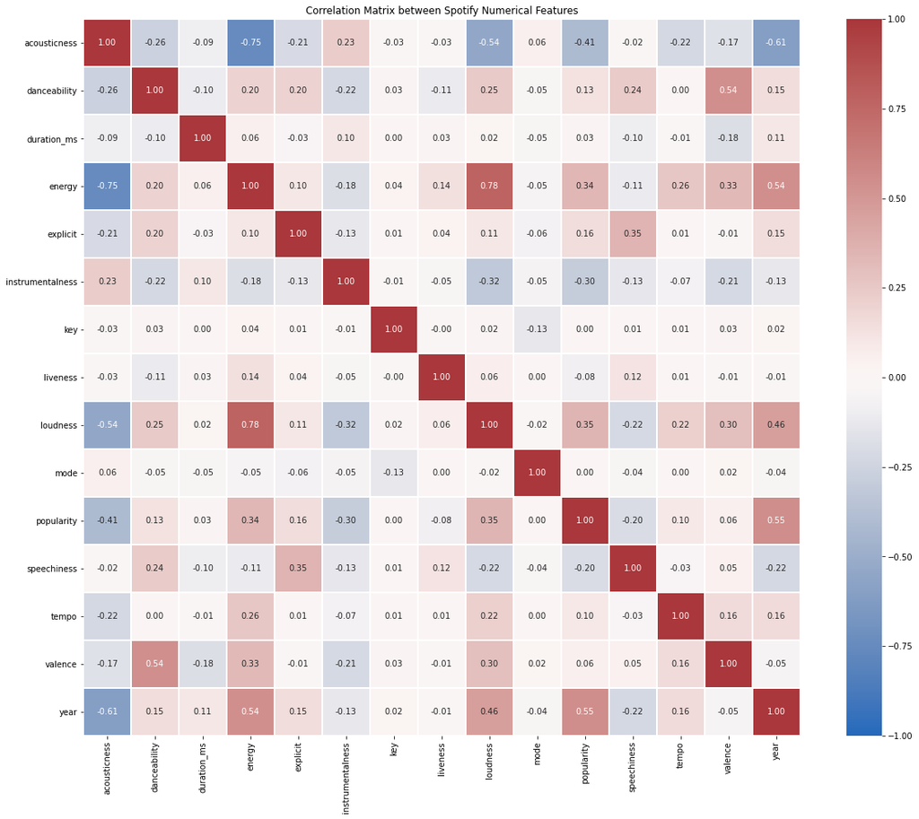

```python
import numpy as np
import matplotlib.pyplot as plt
import seaborn as sns
cor = sp_interest[numeric_column].corr()
plt.figure(figsize=(20, 16))
sns.heatmap(cor, cmap=sns.cm.vlag, annot=True, fmt='.2f', vmin=-1, linewidths=.5, square=True)
plt.title('Correlation Matrix between Spotify Numerical Features')
```

From the Correlation Matrix above, we could notice that some numerical features have correlations to 'popularity', either positive trends or negative trends. For instance, 'year', 'loudness', and 'energy' are positive correlated to 'popularity', while 'acousticness' is negatively correlated to 'popularity'. Since both the positively and negative correlation coefficients are worthy investigating, we will take a closer look at the correlation coefficients to figure out the most interesting relationships.

```python
correlation = cor['popularity'].sort_values(ascending=False)
correlation
```

```
popularity          1.000000
year                0.549709
loudness            0.348913
energy              0.343429
explicit            0.155129
danceability        0.131408
tempo               0.098401
valence             0.059158
duration_ms         0.028229
mode                0.003346
key                 0.002166
liveness           -0.083625
speechiness        -0.200310
instrumentalness   -0.295597
acousticness       -0.412569
Name: popularity, dtype: float64
```

The correlation coefficients are consistent with our observation before. In the numerical features, 'year', 'loudness', and 'energy' are likely to be positively related to 'popularity', while 'acousticness' is negatively related to 'popularity' from the correlation matrix above.

Then, let's look at each single interested feature and its relationship to 'popularity'

First, we look at the 'year' feature individually:

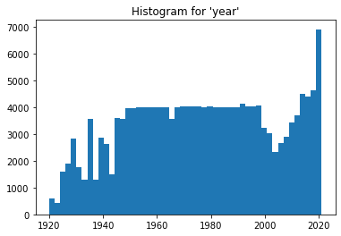

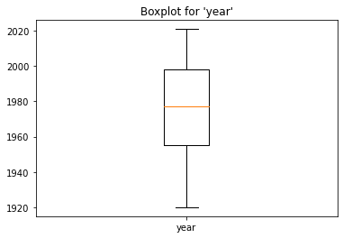

```python
#histogram for 'year' feature
plt.hist(sp_interest['year'],bins = 50)
plt.title("Histogram for 'year'")
plt.show()
#Boxplot for 'year' feature
plt.boxplot(sp_interest['year'],labels = ['year'])
plt.title("Boxplot for 'year'")

plt.show()
```

From the histogram and boxplot above, we notice that the median of songs' released years in our data point is about 1977 and the mode is about 2020. There's no outliers. Also, the distribution of 'year' is slightly skew to left and the standard deviation is about 25.

Then, we look at 'loudness' individually:

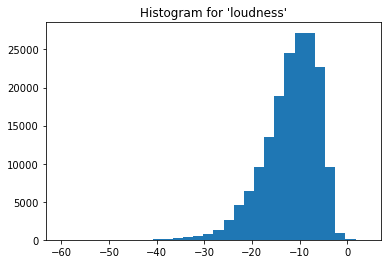

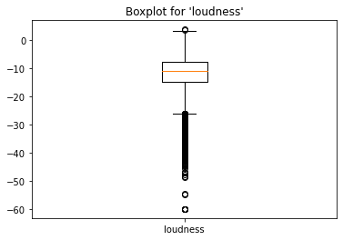

```python
#histogram for 'loudness' feature
plt.hist(sp_interest['loudness'],bins = 30)
plt.title("Histogram for 'loudness'")
plt.show()
#Boxplot for 'loudness' feature
plt.boxplot(sp_interest['loudness'],labels = ['loudness'])
plt.title("Boxplot for 'loudness'")
plt.show()
```

From the histogram and boxplot above, we notice that the median of data points' loudness is about -10 and the mode is also near -10. There's many outliers under -40. Also, the distribution is slightly skew to left and mainly located near -10 with small standard deviation.

At last, we can finally look at 'energy' and 'acousticness' features together for they have similar scales on values:

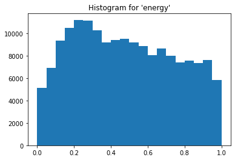

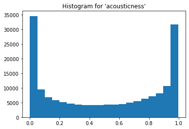

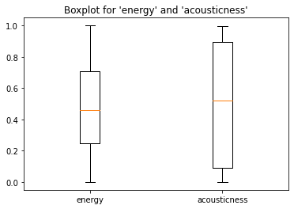

```python
#histogram for 'energy' feature
plt.hist(sp_interest['energy'],bins = 20)
plt.title("Histogram for 'energy'")
plt.show()

#histogram for 'acousticness' feature
plt.hist(sp_interest['acousticness'],bins = 20)
plt.title("Histogram for 'acousticness'")
plt.show()

#Boxplot for 'energy' and 'acousticness' and feature
plt.boxplot(sp_interest[['energy','acousticness']],labels = ['energy', 'acousticness'])
plt.title("Boxplot for 'energy' and 'acousticness'")
plt.show()
```

Next, let's do pairtplots to these most interesting numerical features, together with 'popularity'.

Problem4

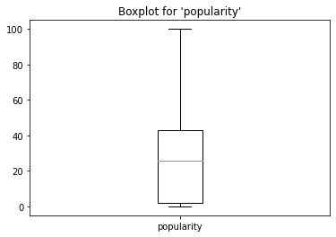

```
Pairplots of Interested numerical features:
```

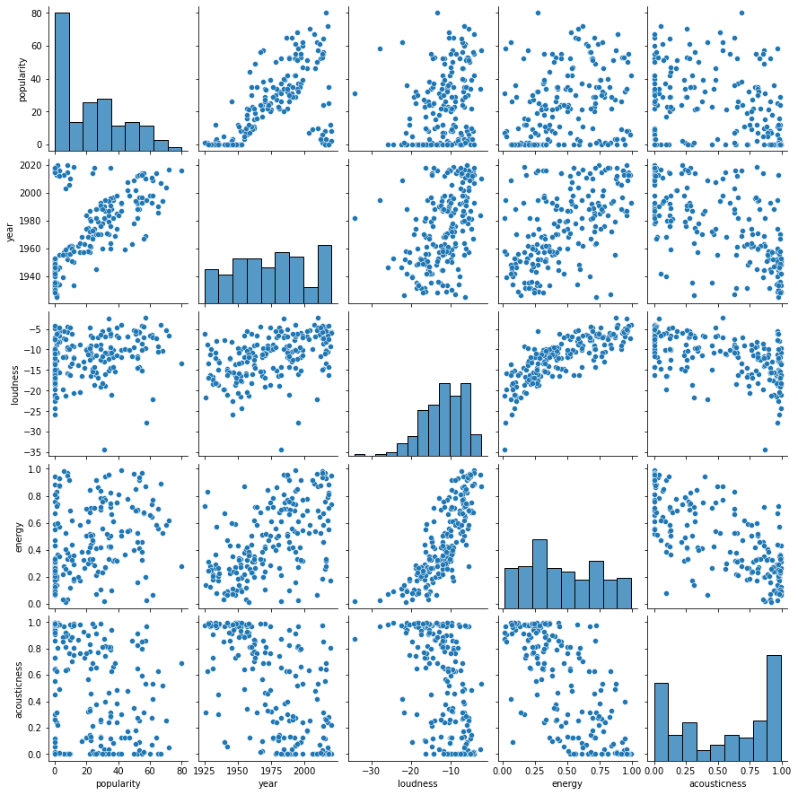

```python
#Boxplot for 'loudness' feature
plt.boxplot(sp_interest['popularity'],labels = ['popularity'])
plt.title("Boxplot for 'popularity'")
plt.show()
#Pairplots of Interested numerical features:
numeric_interested = ['popularity','year','loudness', 'energy', 'acousticness']
sns.pairplot(sp_interest.sample(200), vars= numeric_interested)
print("Pairplots of Interested numerical features:")
plt.show();
```

Above pairplots show the relationships between each pair of the interested numeric features, as well as their respective relationship to 'popularity'.

For 'popularity', its distribution is skew to the right with mode between 0 and 10. The median of 'popularity' is near 25 with range from 0 to 100 and a standard deviation of 20.

Interestingly, from the pair plots, we notice that for 'year', 'loudness', and 'energy', when these features increase, the popularity increases, so they might be positively related to 'popularity'. However, when 'acousticness' increases, the 'popularity' decreases, so 'acousticness' might be negatively related to 'popularity'.

## 3. Asking the Hard Questions

By now we should know all of the ins and outs about this dataset (right?). Let's dive a little deeper into it and see if we can find anything interesting.

### Problem 4

As you worked through the initial phase our this homework, did anything catch your interest? Let's formulate some questions and hypotheses that you could explore in depth.

**Write-up** Formulate and describe a question and a hypothesis to answer it. What inspired your idea (provide specifics from the last section, if any)? How can you use the data to support or reject your hypothesis?

**You response here:** Question: Besides the time factor, what other features of songs are closely correlated to 'popularity'(both positively related and negatively related), so that we might use these features to increase the popularity of the song?

Hypothesis: 'loudness', and 'energy' are positive correlated to 'popularity', while 'acousticness' is negatively correlated to 'popularity' based on datapoints from the same time period.

I get this idea from the interested features we find above in problem three. From the pair plots here Problem4, we could find the relations between these features: 'year', 'loudness', 'energy', 'acousticness' and 'popularity'. However, I notice that unlike new songs which are usually popular among young people, old songs are usually popular among old people. Comparing with young people, a large number of old people do not use Spotify or other apps to listen to musics. Without their fans using those apps, old songs' popularities are usually lower than new songs. Therefore, I wish to get rid of the time factor limitation to figure out what other features of songs are closely correlated to 'popularity'.

First, I will get rid of the time factor 'year' by using data points from the same time period.(I will explain why in question 5). Then, I will try to show that, in this case, the hypothesis features are correlated to 'popularity', using the correlation coefficients and relative graphs. I will rank the correlation coefficient of each features to 'popularity' to show whether the data support or reject my hypothesis. Then, I will train a linear regression model with closely correlated features as inputs and 'popularity' as target, and analyze its test error to figure out whether it's a good idea to only use closely correlated features to predict 'popularity'.

### Problem 5

Let's explore your hypothesis. Find evidence from the data that supports or refutes your hypothesis and present it — recall that as a data scientist, one of you're goals is to discover and communicate your results to your audience, *me*. The more thorough your analysis, the better!

Here's yet another *free* cell; use as many as you need.

First of all, why we have to get rid of the time factor(specifically 'year' in our dataset)?

Below is an analysis of the relationship between 'year' and 'popularity':

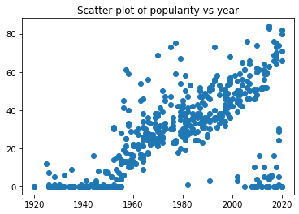

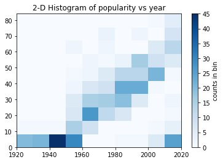

```
correlation coefficient: 0.5497089658949076
```

```python
#since there are too many data points in our data, we randomly take 500 samples
#the reason of sampling remains the same for the following analysis
#plot the scatter plot
sp_sample = sp_interest.sample(500)
plt.scatter(sp_sample['year'],sp_sample['popularity'])
plt.title("Scatter plot of popularity vs year")
plt.show()
#plot the 2-D histogram
plt.hist2d(sp_sample['year'], sp_sample['popularity'], bins=10, cmap='Blues')
cb = plt.colorbar()
cb.set_label('counts in bin')
plt.title("2-D Histogram of popularity vs year")
plt.show()

#find the correlation coefficient between popularity and year
print('correlation coefficient:', correlation.iloc[1])
```

From the scatter plot and 2-D histogram above, we are able to figure out that 'year' is positively correlated to 'popularity'. (correlation coefficient = 0.55)

However, one thing I find interesting is that new songs which released in recent years are likely to have higher popularity than old songs in 1920s or 1940s. This might be caused by factors other than songs themselves. Unlike new songs which are usually popular among young people, old songs are usually popular among old people. However, comparing with young people, a large number of old people do not use Spotify or other apps to listen to musics. Without their fans using those apps, old songs' popularities are usually lower than new songs. When they are popular, modern apps may not even exist and the data couldn't be collected.

Therefore, I wish to the investigate what other features of songs are closely correlated to 'popularity' besides these time factors and historical limitations.

Next, we try to get rid of the time factor 'year' by using data points from the same time period (from 2010 to 2021):

```python
# get data points from 2010 to 2021
sp_modern = sp_interest[sp_interest['year'] > 2009]
sp_modern.shape
```

```
(26022, 16)
```

Then, we first calculate each numerical feature's correlations to each other based on our data points from 2010 to 2021. After that, we use heatmap to make a Correlation Matrix of pairwise correlation values of numerical features based on our data points from 2010 to 2021. At last we rank the correlation coefficient to 'popularity' from high to low. We set the absolute value of correlation coefficient >= 0.2 to be closely correlated to 'popularity'.

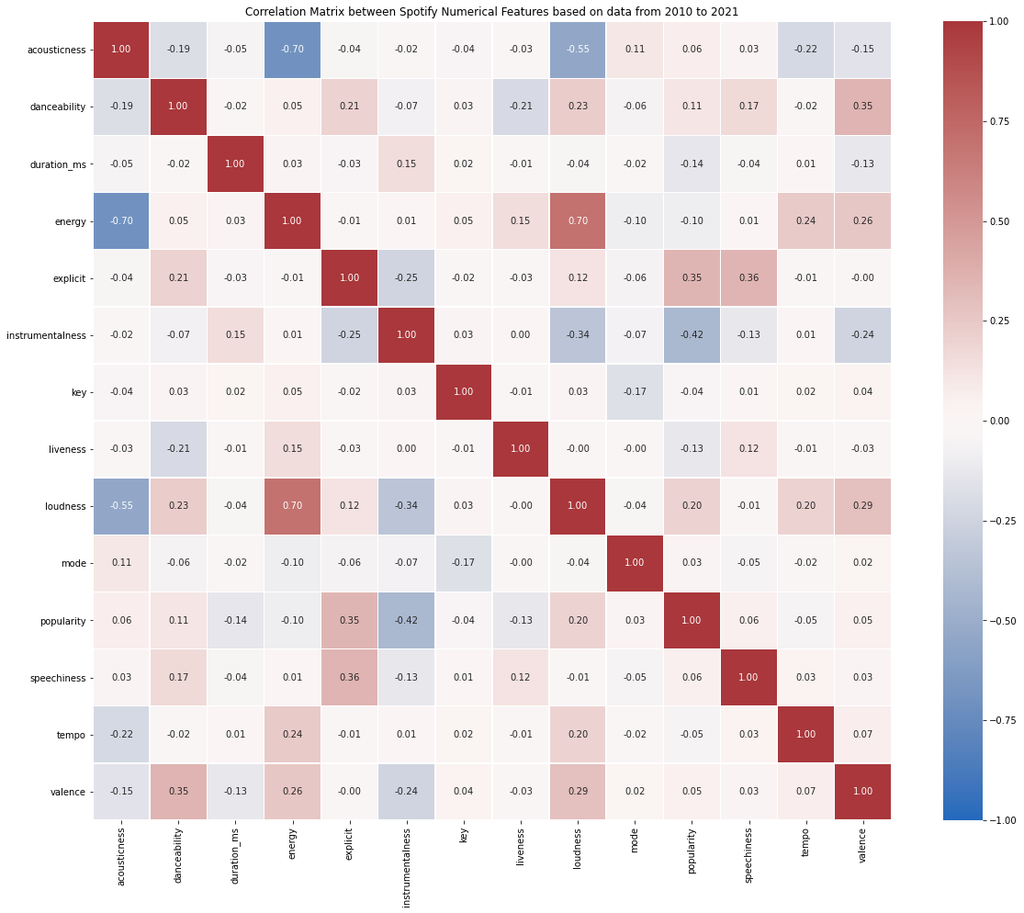

```
popularity          1.000000
explicit            0.350541
loudness            0.202790
danceability        0.113981
acousticness        0.063726
speechiness         0.057298
valence             0.052503
mode                0.027017
key                -0.038027
tempo              -0.054461
energy             -0.095788
liveness           -0.128838
duration_ms        -0.135686
instrumentalness   -0.422098
Name: popularity, dtype: float64
```

```python
new_column = numeric_column.drop('year')
corr = sp_modern[new_column].corr()
plt.figure(figsize=(20, 16))
sns.heatmap(corr, cmap=sns.cm.vlag, annot=True, fmt='.2f', vmin=-1, linewidths=.5, square=True)
plt.title('Correlation Matrix between Spotify Numerical Features based on data from 2010 to 2021')
plt.show()
print(corr['popularity'].sort_values(ascending=False))
```

Interestingly, the result shows that from 2010 to 2021, only 'explicit', 'loudness' and 'instrumentalness' are closely correlated to 'popularity'. 'explicit' and 'loudness' is positively correlated to 'popularity', while 'instrumentalness' are negatively correlated to'popularity', shown in the pair plots below:

```
Pairplots of closely correlated features:
```

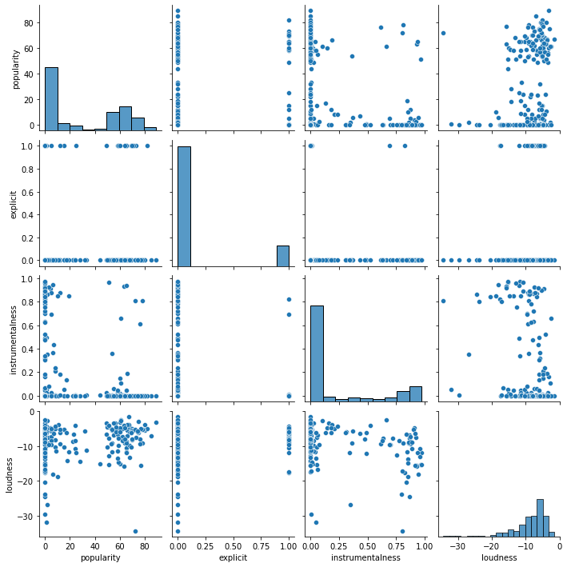

```python
#Pairplots of closely correlated features:
numeric_closely = ['popularity','explicit', 'instrumentalness','loudness']
sns.pairplot(sp_modern.sample(200), vars= numeric_closely)
print("Pairplots of closely correlated features:")
plt.show();
```

This result actually reject my hypothesis. Instead of 'loudness', 'energy' and 'acousticness',  
'explicit', 'instrumentalness',and 'loudness' are the features that closely correlated to 'popularity' based on the data from 2010 to 2021.

Let's train a linear regression model with input features of 'explicit', 'instrumentalness', 'loudness', and the target of 'popularity' based on the data from 2010 to 2021.

```python
from sklearn.linear_model import LinearRegression
from sklearn.model_selection import train_test_split
#get input features X and the target feature y.
X = sp_modern[['explicit', 'instrumentalness','loudness']]
y = sp_modern['popularity']
model = LinearRegression()
#do a test/train split
X_train, X_test, y_train, y_test = train_test_split(X, y, test_size=0.3, random_state=10)
model.fit(X_train, y_train)
```

```
LinearRegression()
```

Now we have our model. Let's analyse the model's test errors.

```python
from sklearn.metrics import mean_squared_error
y_prediction = model.predict(X_test)
rmse = np.sqrt(mean_squared_error(y_test, y_prediction))
f'RMSE: {rmse}'
```

```
'RMSE: 26.693771686885302'
```

The model's test error RMSE is not small(26.7), so it's not a good idea to use only 'explicit', 'instrumentalness', and 'loudness' to predict 'popularity'. However, based on the correlation coefficients we get, 'explicit', 'instrumentalness', and 'loudness' are still closely correlated to 'popularity', which actually rejects my hypothesis('loudness', 'energy' and 'acousticness').

Therefore, results might show us a new conclusion that features that are closely related to 'popularity' might change based on different time period. To further investigate the conclusion, we start a new analysis. This time, we will use data points from 1998 to 2009.

```python
# get data points from 1998 to 2009
sp_modern_two = sp_interest[sp_interest['year'] > 1997]
sp_modern_two = sp_modern_two[sp_modern_two['year'] < 2010]
sp_modern_two.shape
```

```
(17706, 16)
```

Then, we first calculate each numerical feature's correlations to each other based on our data points from 1998 to 2009. After that, we use heatmap to make a Correlation Matrix of pairwise correlation values of numerical features based on our data points. At last we rank the correlation coefficient to 'popularity' from high to low. We set the absolute value of correlation coefficient >= 0.2 to be closely correlated to 'popularity'.

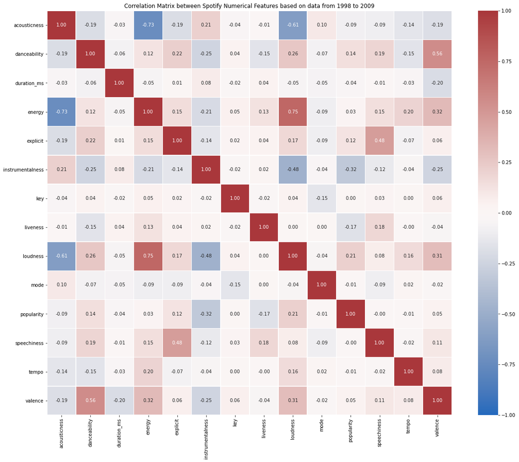

```
popularity          1.000000
loudness            0.213768
danceability        0.144749
explicit            0.120145
valence             0.046730
energy              0.027541
key                 0.002557
speechiness        -0.004623
mode               -0.008490
tempo              -0.009717
duration_ms        -0.035612
acousticness       -0.085332
liveness           -0.165826
instrumentalness   -0.316769
Name: popularity, dtype: float64
```

```python
new_column = numeric_column.drop('year')
corr = sp_modern_two[new_column].corr()
plt.figure(figsize=(20, 16))
sns.heatmap(corr, cmap=sns.cm.vlag, annot=True, fmt='.2f', vmin=-1, linewidths=.5, square=True)
plt.title('Correlation Matrix between Spotify Numerical Features based on data from 1998 to 2009')
plt.show()
print(corr['popularity'].sort_values(ascending=False))
```

This time, only 'loudness' and 'instrumentalness' are closely correlated to 'popularity'. 'loudness' is positively correlated to 'popularity', while 'instrumentalness' is negatively correlated to'popularity'.

This results support our new conclusion that features that are closely related to 'popularity' might change based on different time periods that we choose to divide our dataset.

To make the new conclusion more persuasive, we will start a third analysis based on data points from 1979 to 1988.

```python
# get data points from 1979 to 1988
sp_modern_three = sp_interest[sp_interest['year'] > 1978]
sp_modern_three = sp_modern_three[sp_modern_three['year'] < 1989]
sp_modern_three.shape
```

```
(20050, 16)
```

Then, we first calculate each numerical feature's correlations to each other based on our data points from 1979 to 1988. After that, we use heatmap to make a Correlation Matrix of pairwise correlation values of numerical features based on our data points. At last we rank the correlation coefficient to 'popularity' from high to low. We set the absolute value of correlation coefficient >= 0.2 to be closely correlated to 'popularity'.

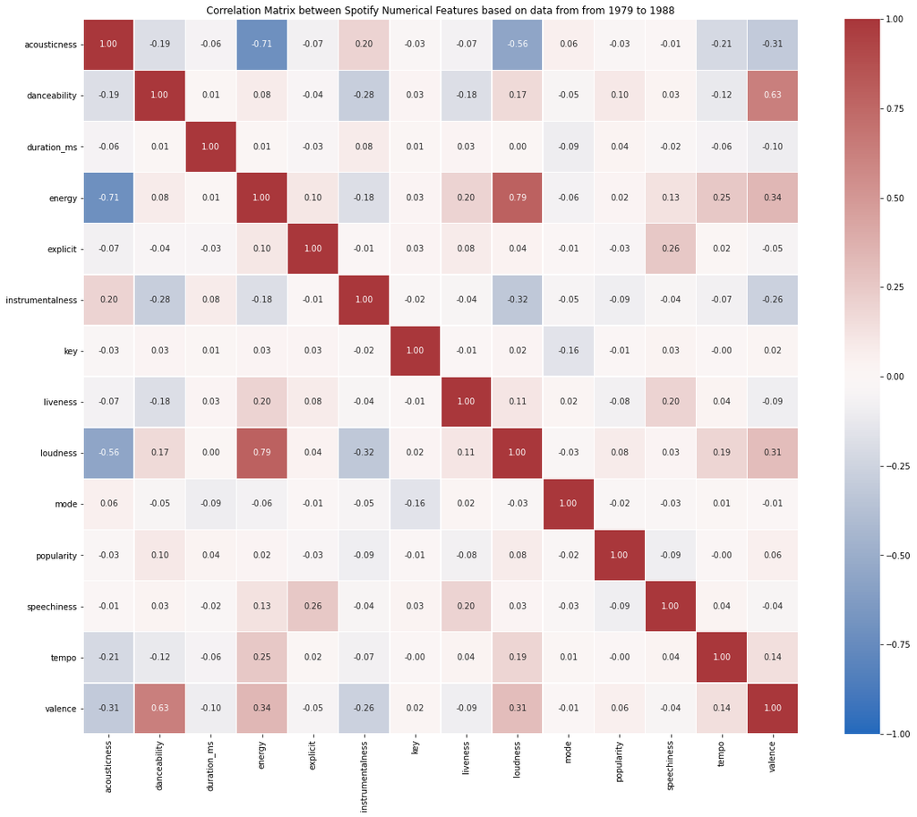

```
popularity          1.000000
danceability        0.097791
loudness            0.082526
valence             0.060547
duration_ms         0.038872
energy              0.024954
tempo              -0.000687
key                -0.005237
mode               -0.018876
acousticness       -0.029196
explicit           -0.031881
liveness           -0.076064
speechiness        -0.087505
instrumentalness   -0.088867
Name: popularity, dtype: float64
```

```python
new_column = numeric_column.drop('year')
corr = sp_modern_three[new_column].corr()
plt.figure(figsize=(20, 16))
sns.heatmap(corr, cmap=sns.cm.vlag, annot=True, fmt='.2f', vmin=-1, linewidths=.5, square=True)
plt.title('Correlation Matrix between Spotify Numerical Features based on data from from 1979 to 1988')
plt.show()
print(corr['popularity'].sort_values(ascending=False))
```

This time, no particular feature is closely correlated to 'popularity'. This results also confirm our new conclusion that features that are closely related to 'popularity' might change based on different time period.

### Problem 6

Did you find anything interesting in Problem 5? If you did, tell me about it. What recommendations do you have for songwriters? What recommendations do you have for aspiring songwriters looking to make it big on Spotify?

It would be lovely if you could provide links to key figures in your discussion. See [this StackOverflow question](https://stackoverflow.com/questions/28080066/how-to-reference-a-ipython-notebook-cell-in-markdown) for details.

**You response here:** Yes, my finding in Problem 5 actually reject my initial hypothesis(one). Instead of my hypothesis ('loudness', 'energy' and 'acousticness'), 'explicit', 'instrumentalness',and 'loudness' are actually the features that closely correlated to 'popularity' besides the time factor "year" based on the data from 2010 to 2021.

Then, I have developed a new conclusion(two) that features that are closely related to 'popularity' might change based on different time periods we choose to divide our dataset. After that, I made some new analyses to make my new conclusion more persuasive (three & four).

For todays' aspiring songwriters who wish to increase their songs' popularities on Spotify, I recommend them to increase the values of 'explicit' and 'loudness', while reduce the value of 'instrumentalness'. This is because, based on my first analysis (five), 'explicit', 'loudness' and 'instrumentalness' are closely correlated to 'popularity'. 'explicit' and 'loudness' are positively correlated to 'popularity', while 'instrumentalness' is negatively correlated to'popularity'.

### Problem 7

One last step that we shouldn't skip is reviewing the data acquisition method. There are often times where the data you need doesn't exist and you need to go collect it. Based on your analysis of the data set, which features were informative and which weren't? What information that was missing from this dataset do you think would be helpful to have for next time?

**You response here:** Based on my analysis of the data set, I think most numerical features are infomative like 'loudness', 'energy', 'acousticness', 'explicit', 'instrumentalness', and so on. They can provide quantified descriptions of a particular song and help us analyze. However, for categorical types, I think 'name' are not informative (or too informative) that each song usually has a unique name, so we can't find a particular pattern between 'name' and 'popularity'. Next time, I think if we add a categorical feature about 'music_type' might be helpful for us to analyze the dataset. The information of music types is important and often related to the popularity. However, it's missing from current data.

And that's it! Remember to review your work and make sure it is well presented and organized. Not everyting you coded up needs to remain in your submission. **[Does [this cell] spark joy?](https://i.kinja-img.com/gawker-media/image/upload/s--iW_3HGbT--/c_scale,dpr_2.0,f_auto,fl_progressive,q_80,w_800/oruf4oavtj5vpmvaquew.jpg)** You are always trying to communicate your findings to somebody, *maybe even yourself*.